# Regression Diagnostics

## Basic residual plots

We will use `m1 <- lm(y1 ~ x1, data = anscombe)`

How to construct residual plot:

1. Calculate \(\hat{e}_i = y_i - \hat{y}_i\) for each point in your data set (also available as `m1$res`).
2. Create a scatter plot with the residuals on the y axis. On the x-axis you can plot either the x-coordinates or the fitted values (_i).

```r
plot(anscombe$x1, m1$res) # x versus residuals
plot(m1$fit, m1$res) # x versus fitted
plot(m1, 1) # built-in function
```

## Residual vs. X for each dataset

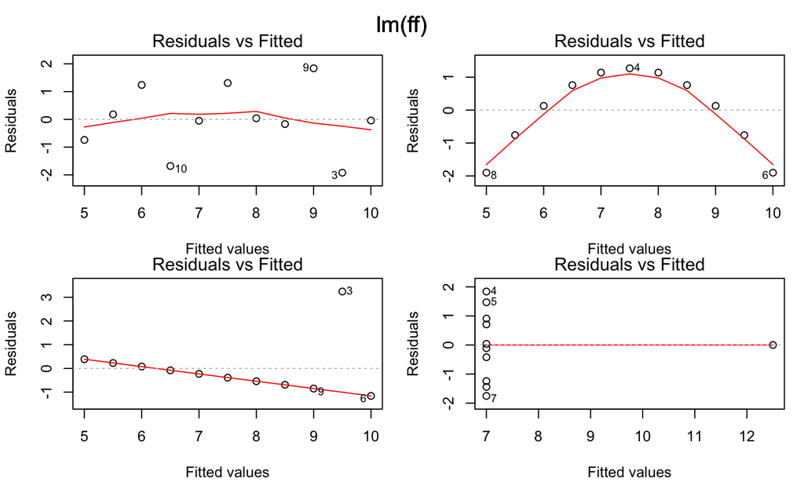

## Anscombe I

1. The conditional mean of Y|X is a linear function of X. *OK!*
2. The variance of Y|X is the same for any X. *OK!*
3. The errors (and thus the Y|X are independent of one another). *OK!*
4. The errors are normally distributed with mean zero. *Probably ok?*
5. No "outliers". *OK!*

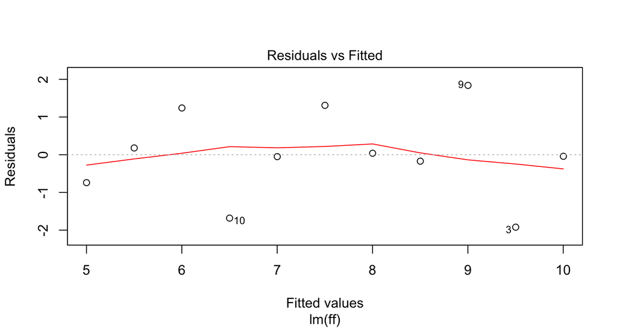

## Anscombe II

1. The conditional mean of Y|X is a linear function of X. *Looks quadratic*
2. The variance of Y|X is the same for any X. *OK!*
3. The errors (and thus the Y|X are independent of one another). *Could be an issue, but probably not.*
4. The errors are normally distributed with mean zero. *Looks unlikely*
5. No "outliers".*8 and 6 maybe?*

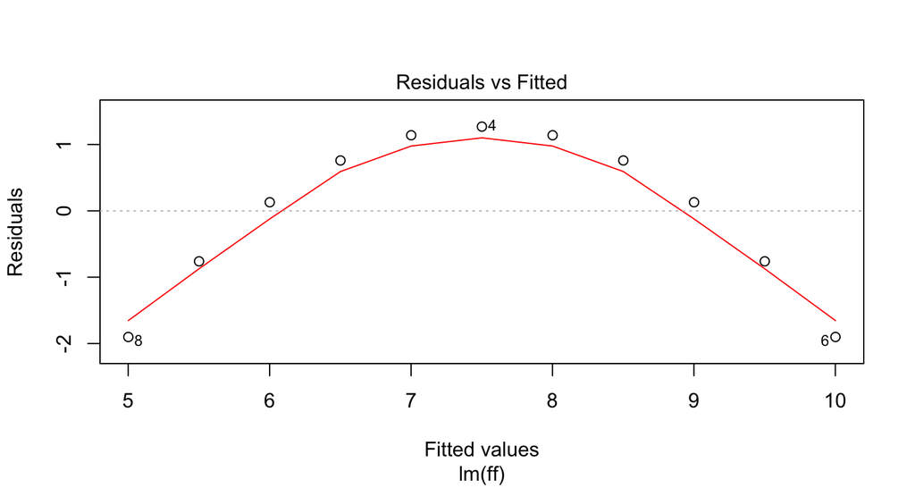

## Anscombe III

1. The conditional mean of Y|X is a linear function of X. *Perfectly linear, but we've fit the wrong line!*
2. The variance of Y|X is the same for any X. *Looks like a problem.*
3. The errors (and thus the Y|X are independent of one another). *Hard to tell.*
4. The errors are normally distributed with mean zero. *Hard to tell.*
5. No "outliers". *Whoops! Point 3 is a glaring problem.*

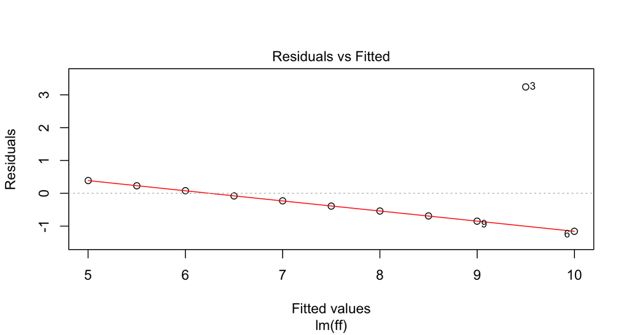

## Anscombe IV

1. The conditional mean of Y|X is a linear function of X. *Possibly, though the X doesn't appear to have much predictive power.*
2. The variance of Y|X is the same for any X. *Hard to say.*
3. The errors (and thus the Y|X are independent of one another). *Hard to tell.*
4. The errors are normally distributed with mean zero. *Looks more uniform.*
5. No "outliers". *The slope of the line is being completely determined by one point!*

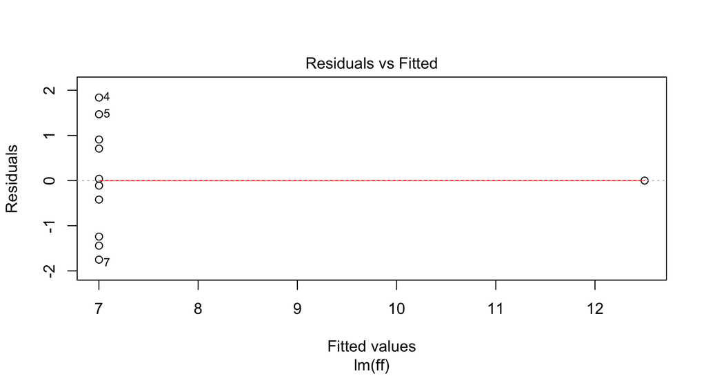

## Assessing Normality

We can check the assumption that the errors are normal by looking at the distribution of the residuals. Difficult to do in a residual plot, so we use a QQ plot (for quantile-quantile), aka normal probability plot.

*Quantile*: The \(j^{th}\) quantile, \(q_j\), is the value of a random variable \(X\) that fulfills:

\[ P(X \le q_j) = j \]

For the standard normal distribution, \(q_{.5} = 0\), \(q_{.025} = -1.96\), \(q_{.975} = 1.96\).

## Constructing a QQ plot

1. Standardize your residuals. \[ \tilde{e}_i = \frac{\hat{e}_i - \bar{\hat{x}}}{s} \]
2. If you have \(n\) standardized residuals, you can consider the lowest to be the \(1/n\) quantile, the second lowest, the \(2/n\) quantile, the median to be the \(.5\) quantile, etc.
3. Look up these values for the standard normal distribution and find what the appropriate quantiles would be (this is what `qnorm()` does). These become your theoretical quantiles.
4. Plot the theoretical quantiles against the standardized residuals.

## Constructing a QQ plot

1. Standardize your residuals. \[ \tilde{e}_i = \frac{\hat{e}_i - \bar{\hat{x}}}{s} \]
2. If you have \(n\) standardized residuals, you can consider the lowest to be the \(1/n\) quantile, the second lowest, the \(2/n\) quantile, the median to be the \(.5\) quantile, etc.
3. Look up these values for the standard normal distribution and find what the appropriate quantiles would be (this is what `qnorm()` does). These become your theoretical quantiles.
4. Plot the theoretical quantiles against the standardized residuals.

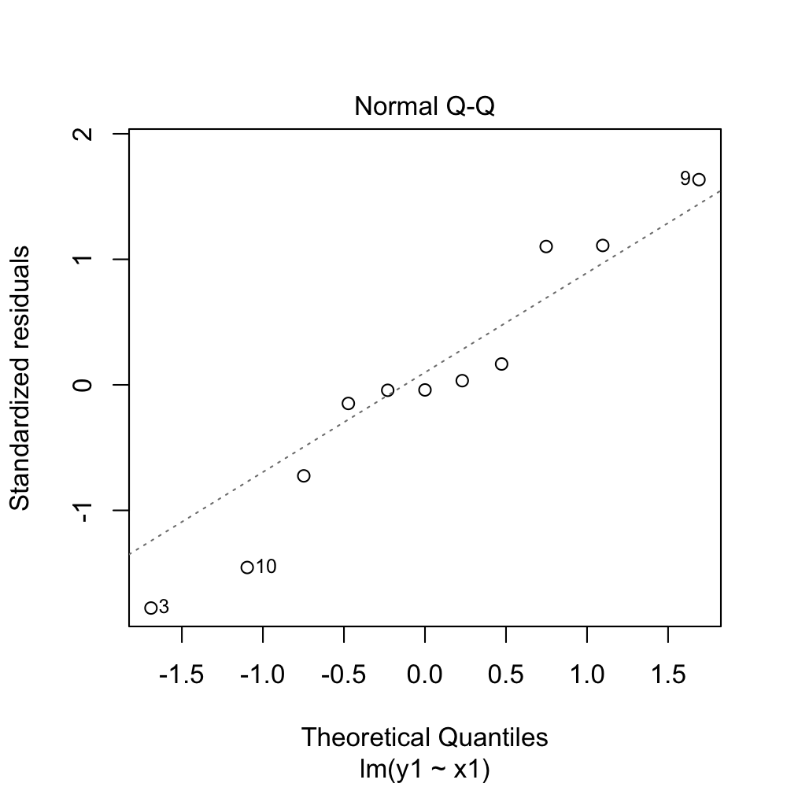

```r
plot(m1, 2)
```

## Interpreting a QQ plot

- Perfectly normally distributed residuals would align along the identify line.
- Short tails will veer of the line horizontally.
- Long tails will veer off the line vertically.
- *Expect some variation, even from normal residuals!*

## Normal residuals

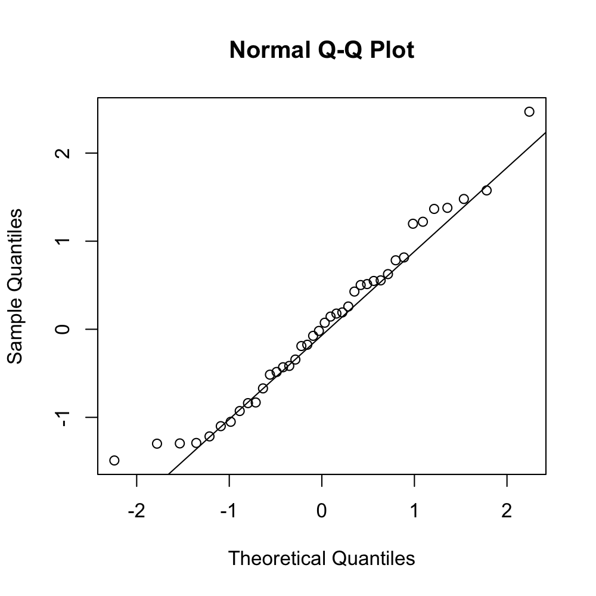

```r
x <- rnorm(40)
qqnorm(x)
qqline(x)
```

## Heavy tailed residuals

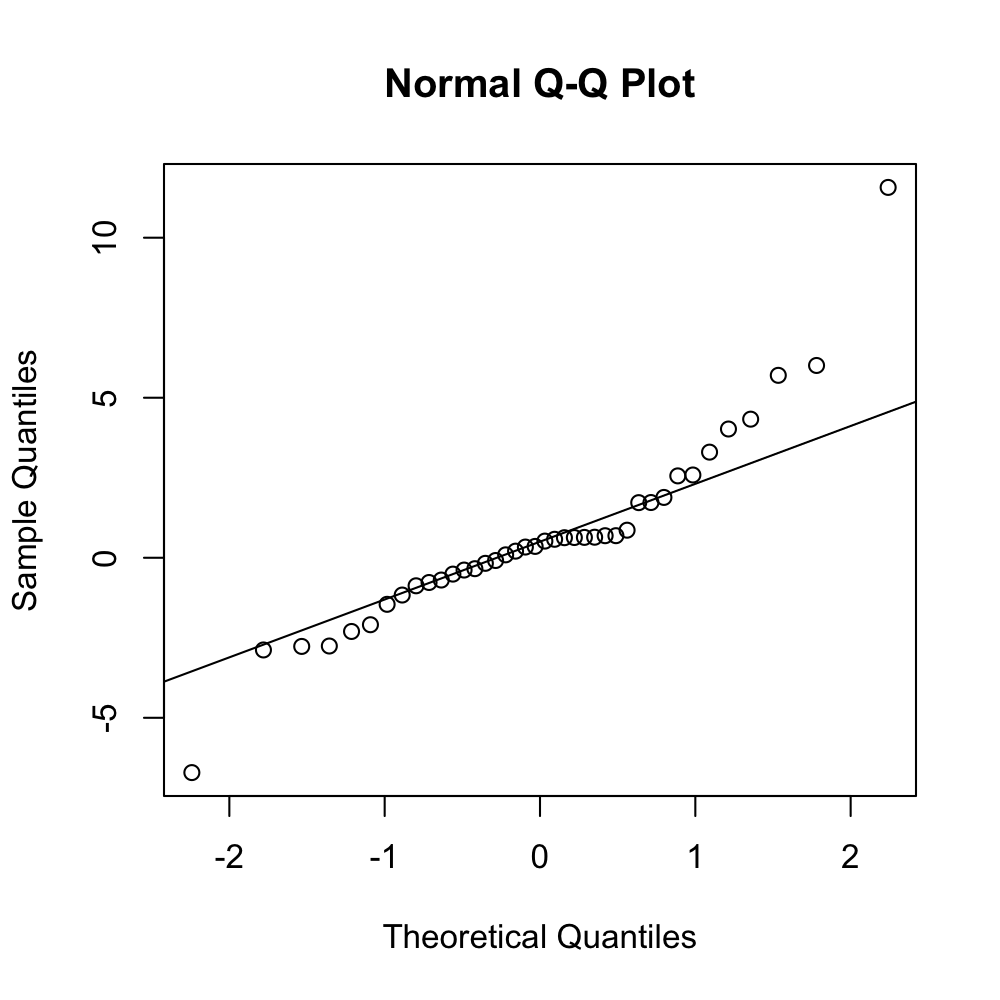

```r
x <- rt(40, 1)
qqnorm(x)
qqline(x)
```

## Returning to Anscome 1

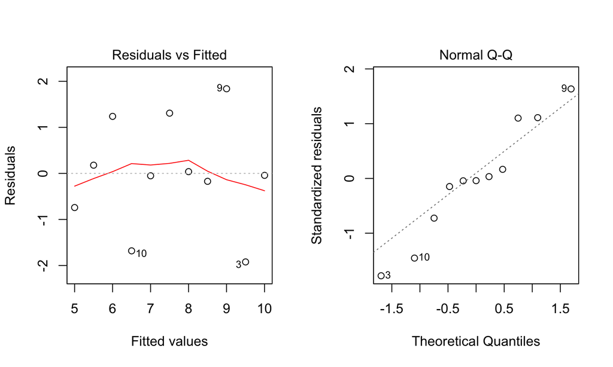

## Checking constant variance

Example: We will use R's `quakes` data set, which gives the locations of 1000 seismic events of MB > 4.0 occuring near Fiji since 1964.

```r
data(quakes)
head(quakes)
```

```
     lat   long depth mag stations
1 -20.42 181.62   562 4.8       41
2 -20.62 181.03   650 4.2       15
3 -26.00 184.10    42 5.4       43
4 -17.97 181.66   626 4.1       19
5 -20.42 181.96   649 4.0       11
6 -19.68 184.31   195 4.0       12
```

We will model the number of stations reporting the quake (`quakes$stations`) as a function of magnitude (`quakes$mag`).

## Fiji quakes data

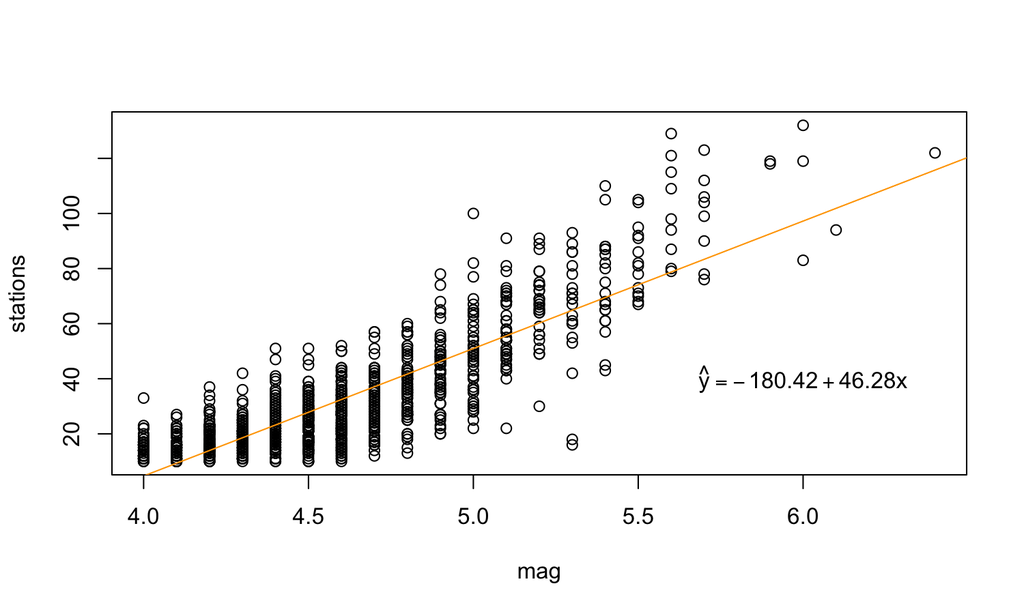

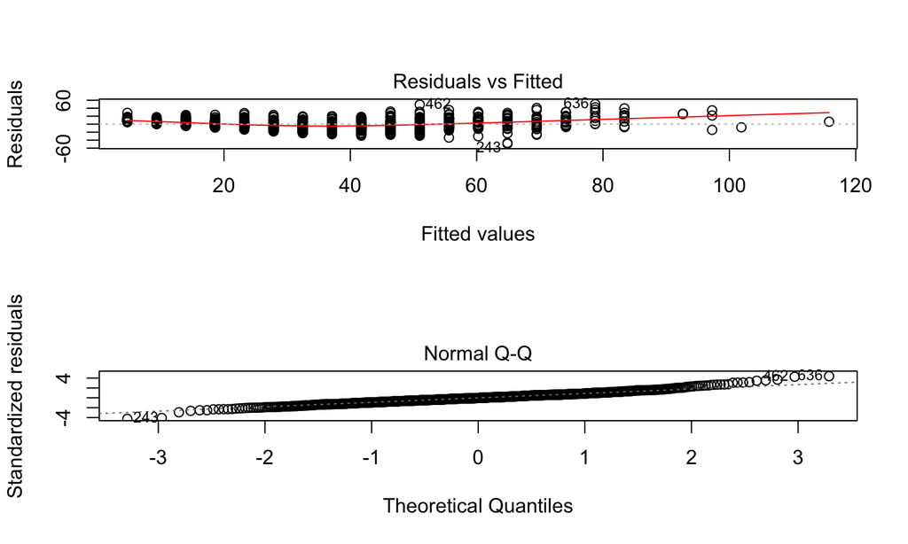

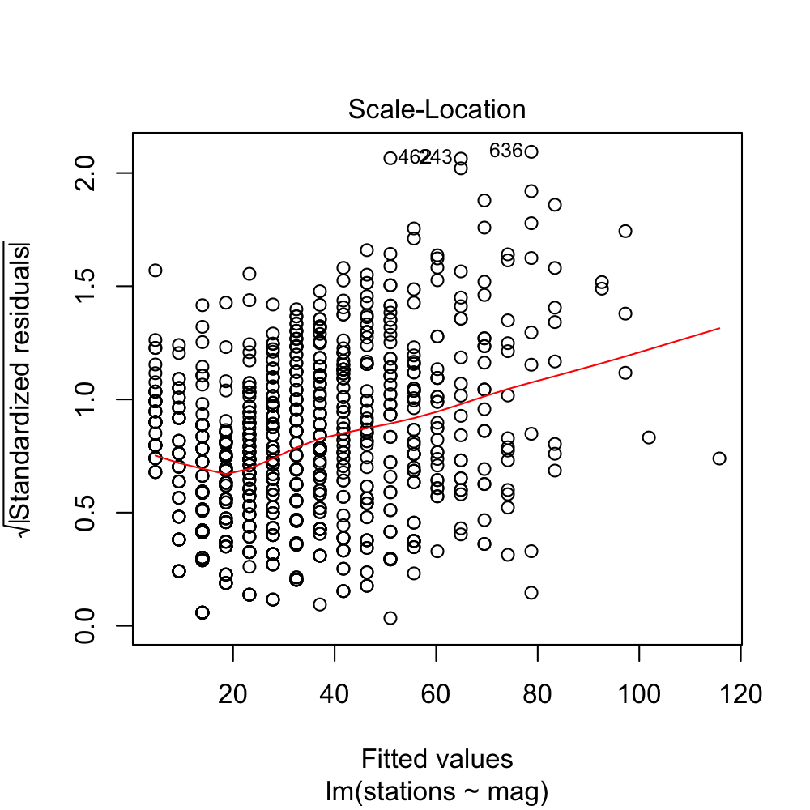

```r
par(mfrow=c(1,1))
plot(m1, 3)
```

## Checking constant variance

- The scale location plot transforms the residuals to make non-constant variance (heteroscedasticity) more apparent.
- The red line is a guide: flat = constant variance.
- The basic residual plot can also be used, but it's a bit more difficult to tell (also, *that* red line refers to the linear trend).

## Outliers and Leverage

## Outliers, leverage, influence

**Outliers** are points that don't fit the trend in the rest of the data.

Calling a point an outlier is vague.

- Outliers can be the result of spurious or real processes.
- Outliers can have varying degrees of influence.
- Outliers can conform to the regression relationship (i.e being marginally outlying in X or Y, but not outlying given the regression relationship).

## Leverage and (possibly) influence

**Leverage** measures the weight given to each point in determining the regression line.. **High leverage points** have the potential to have an unusually large influence on the fitted model.

**Influence** measures how different the regression line would be without a given point. **Influential points** are high leverage points that cause a very different line to be fit than would be with that point removed.

- Being high-leverage is a necessary condition for being highly influential

## High leverage, low influence

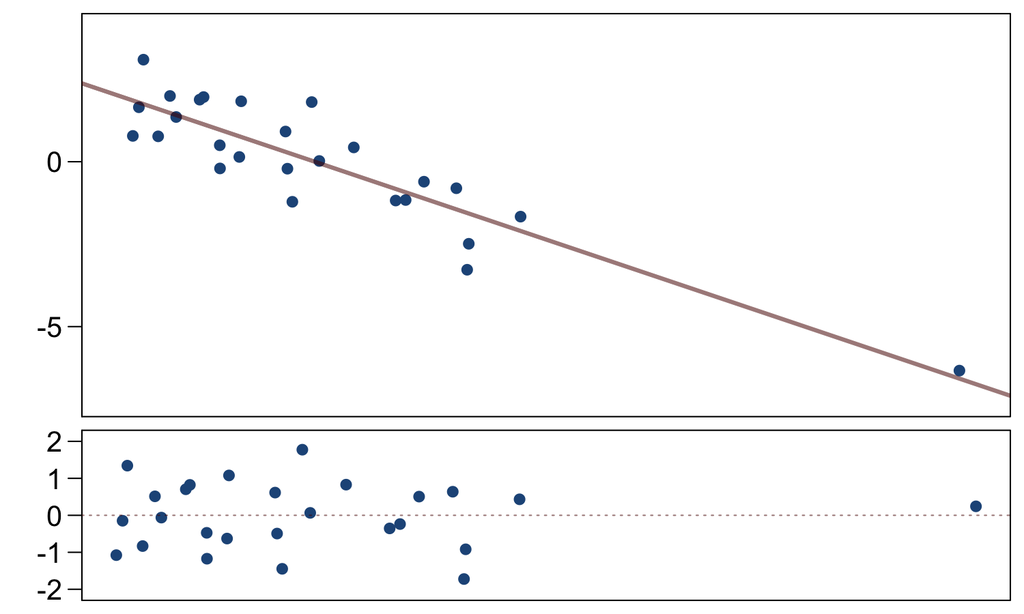

## High leverage, high influence

We can data on the surface temperature and light intensity of 47 stars in the star cluster CYG OB1, near Cygnus (`library(faraway);data(start)`).

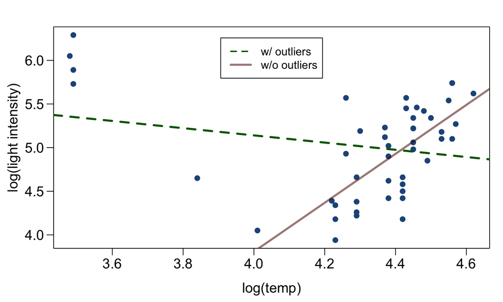

## High Influence

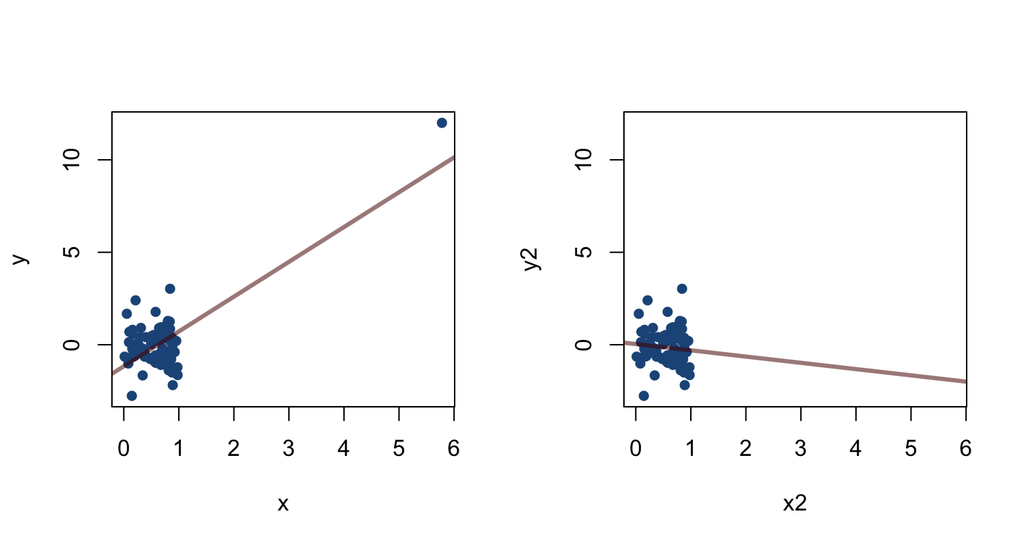

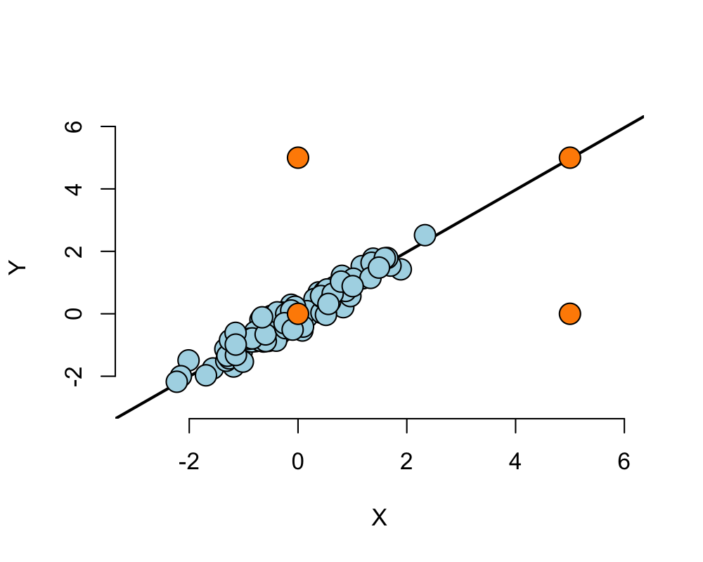

- Upper left: low leverage, low influence, outlies in a way not conforming regression relationship.
- Lower left: low leverage, low influence and is not to be an outlier in any sense.
- Upper right: high leverage, but chooses not to extert it and would have low actual influence by conforming to the regression relationship
- Lower right hand point has high leverage and (if included) high influence

## Quantifying leverage: \(h_{ii}\)

We need a metric for the leverage of \(x_i\) that incorporates

1. The distance \(x_i\) is away from the bulk of the \(x\)'s.
2. The extent to which the fitted regression line is attracted by the given point.

\[ h_{ii} = \frac{1}{n} + \frac{(x_i - \bar{x})^2}{\sum_{j = 1}^n(x_j - \bar{x})^2} \]

## What is "high" leverage?

**Rule of Thumb**: in simple regression, a point has "high leverage" if \(h_{ii} > 4/n\).

```r
m1 <- lm(y ~ x)
h <- lm.influence(lm(y ~ x))$hat
```

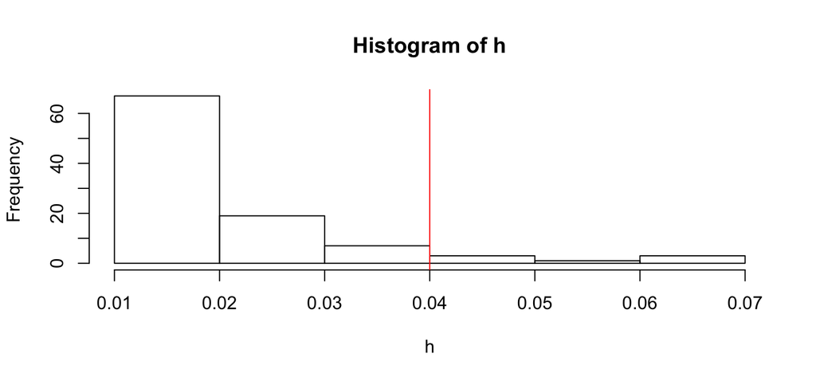

## Quantifying influence in R

- `rstandard` - standardized residuals, residuals divided by their standard deviations)
- `rstudent` - standardized residuals, residuals divided by their standard deviations, where the ith data point was deleted in the calculation of the standard deviation for the residual to follow a t distribution
- `hatvalues` - measures of leverage
- `dffits` - change in the predicted response when the \(i^{th}\) point is deleted in fitting the model.
- `dfbetas` - change in individual coefficients when the \(i^{th}\) point is deleted in fitting the model.
- `cooks.distance` - overall change in coefficients when the \(i^{th}\) point is deleted.

## Standardized residuals

To be sure all of our residuals are assessed on equal footing, we divide each one by our estimate of it's standard deviation.

\[ r_i = \frac{\hat{e}}{s \sqrt{1 - h_{ii}}} \]

Where \(s\) is our usual estimate of \(\sigma\).

Observations with high standardized residuals can be considered *outliers*. Rule of thumb: \(|r_i| > 2\) for small data, \(|r_i| > 4\) for large.

## Why standardize?

We will need to assess whether the assumption of errors with constant variance is reasonable.

What if the non-constant variance that we observe isn't a property of the *errors* but the non-constant variance that goes into making the prediction from which the *residuals* are calculated?

## Diagnostics and Multiple Regression

## Diagnostics and Multiple Regression

In **multiple regression**, in general, you **cannot infer** the structure you see in the residuals vs fitted plot as being the structure that was misspecified. - Non-constant variance in the residuals doesn't neccessarily suggest non-constant variance in the errors. - Non-linear structures don't necessarily suggest a non-linear mean function.

The only conclusion you can draw is that *something* is misspecified.

## So now what?

- Although several types of invalid models can create non-constant variance in the residuals, a valid model will always be structureless.
- If you can be sure you have a good mean function, then the residual plot is more informative.
- We can use **Added Variable Plots** to assess how much each variable adds to your model.

## Added variable plots

Consider the Andrew Bray's NYC restaurant data, with which we'd like to build the model:

\[ Price \sim Food + Decor + Service + East \]

We can assess the isolated effect of each predictor on the response with a series of simple scatterplots…

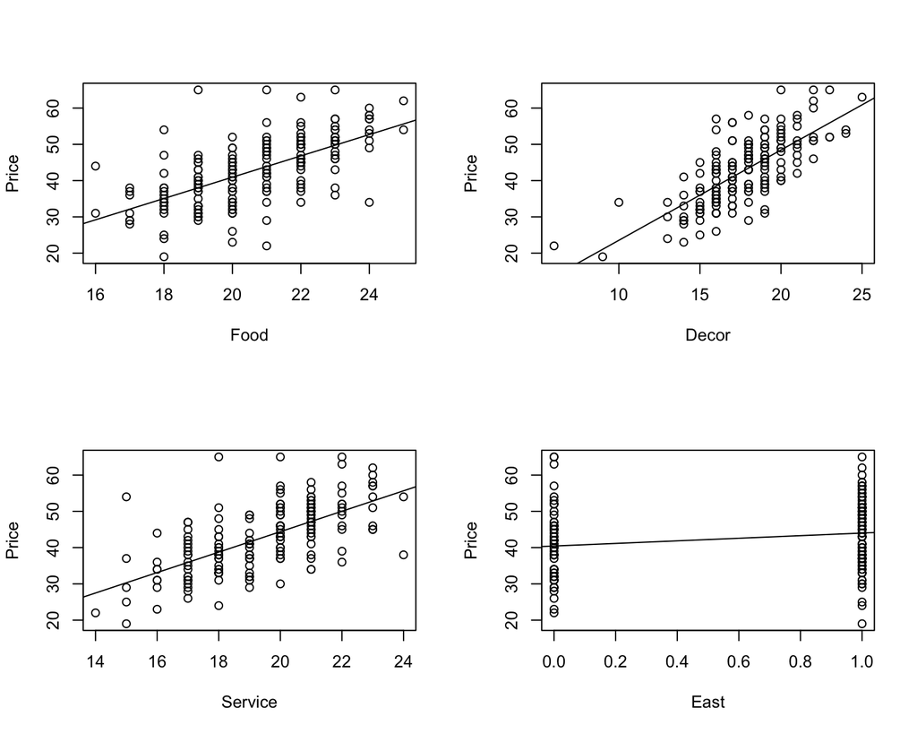

## Added variable plots

An added variable plot tells you how much a given predictor \(x_i\) can explain the response after the other predictors have been taken into account. They plot:

- On the y-axis, the residuals from the model predicting the response without \(x_i\).
- On the x-axis, the residuals from predicting \(x_i\) using those same predictors.

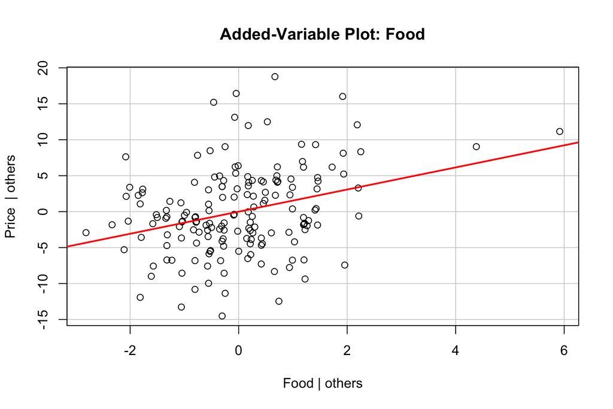

```r
library(car)
m1 <- lm(Price ~ Food + Decor + Service + East, data = nyc)
avPlot(m1,variable = "Food")
```

- We'll go over how to do this in lab…

## How to use AVP

1. AVPs can be used to assess whether it makes sense to include an additional variable in the model (similar to looking at the p-value of the predictor).
2. They're a bit more informative, though, since they would also indicate if the relationship between that predictor and the response is linear in the context of the other variables.

## \(Y\) versus \(\hat{Y}\)

Shows whether your model is doing a good job of modeling the response. If it is, you'll see points along the identity line. If not, there will be a non-linear structure to correct.

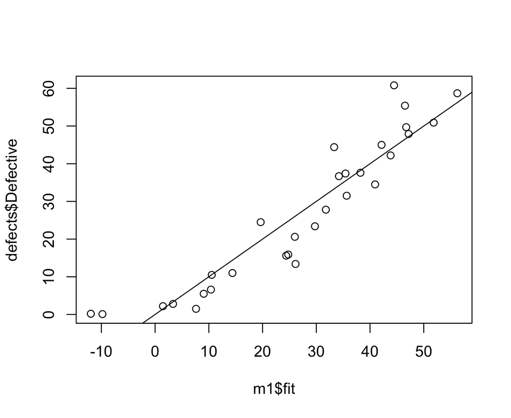

## Marginal model plot

- Standardized residual plots and plots of \(y\) on \(\hat{y}\) can suggest that something is amiss but not reveal the root cause.
- We need to be sure that the structure in the *data* is being mirrored well by the structure in our *model*.
- This comparison is made for each predictor using the **marginal model plot**.

**Marginal Model Plots** are used to assess the marginal relationship between each predictor and the response.

- It compares the fit from the model with the nonparametric fit to the scatterplot.
- If your model is well-specified, these two lines will be close to coincident.

## Example MMP

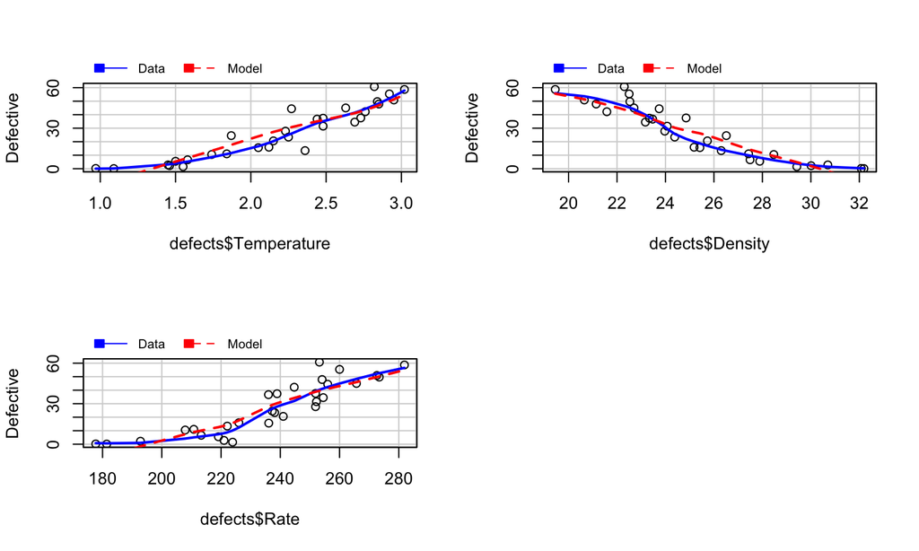

-We will make these in lab…

## Recap

## Summary

- Residual QQ plots investigate normality of the errors.
- Leverage measures (hat values) can be useful for diagnosing data entry errors.
- Influence measures get to the bottom line, 'how does deleting or including this point impact a particular aspect of the model'.

## Always do residual plots

- Patterns in your residual plots generally indicate some poor aspect of model fit. These can include:
- Heteroskedasticity (non constant variance).
- Missing model terms.
- Temporal patterns (plot residuals versus collection order).

## How do I use all of these things?

- Understand what diagnostic tools are trying to accomplish and use them judiciously.
- Not all of the measures have meaningful absolute scales. You can look at them relative to the values across the data.
- They probe your data in different ways to diagnose different problems.

## Diagnostics Summary

## Diagnostics Summary

Before drawing any conclusions from a regression model, we must be confident it is a valid way to model the data. Our model assumes:

- **Linearity**: the conditional mean of the response is a linear function of the predictors.
- The errors have **constant variance** and are **uncorrelated**.
- The errors are **normally distributed with mean zero**.

It's also sensible to build a model with:

- No highly influential points.
- Low multicollinearity.

## Main goal: think differently

How you might have thought before:

- your p-values = f(your data)

How I hope you think now:

- your p-values = f(your data, your assumptions)